## HOMEWORK 4 Ivan Sanchez Fernandez

Download the following data from https://www.dropbox.com/sh/rlj714terrzakc7/AACELk752w4GPAsJXYi8Vbb5a? dl=0 . PRAD_norm_counts.txt - Gene Expression data from patients with prostate cancer adenocarcinoma (TCGA dataset). Normalized RNAseq counts on 86 matched tumor-normal samples and 55,635 genes. Each row reports the expression levels of each gene across the samples. . PRAD_sample_info.txt - Labels associated to the samples (“Primary Tumor” and “Solid Tissue”) . RES_DESeq2_PRAD.txt - List of genes differentially expressed in Primary tumors with respect to Solid Tissue

## Exercise 1

Load PRAD dataset and the labels on the samples into your R workspace.

```r
#I load the dataframes and check if they look reasonable by inspecting the first few rows and columns
PRADnorm <- read.table("D:\\BMI715 Computing Skills for Biomedical Sciences\\Homework4\\PRAD_norm_counts.txt",
                       header = TRUE, sep = "")
PRADnorm[1 : 10, 1 : 5]
```

```
##          TCGA_HC_8260_11A TCGA_HC_8259_11A TCGA_EJ_7123_11A
## TSPAN6         4043.35607       3585.40222       1801.94582
## TNMD             10.55982         20.66773         15.61253
## DPM1           1642.05241       1894.24258       1292.58713
## SCYL3          1157.35656       1435.95808        960.82093
## C1orf112        249.21181        250.70858        199.71024
## FGR             234.42806        343.26407        497.64930
## CFH            1489.99097       3100.15982       3125.10748
## FUCA2          2983.14988       3110.04439       2176.64647
## GCLC           4185.91367       3878.34486       2907.83314
## NFYA           2028.54192       1751.36565       1630.85854
##          TCGA_G9_6496_01A TCGA_EJ_7781_01A
## TSPAN6         5351.86640      3956.467495
## TNMD             10.03726         5.329772
## DPM1           1106.10592      1359.980183
## SCYL3           855.17445      1591.825270
## C1orf112        150.55888       242.504631
## FGR             407.51271       300.243829
## CFH             548.03433      1654.005944
## FUCA2          3743.89754      3276.921551
## GCLC           2443.06879      4231.839054
## NFYA           2322.62169      2410.833584
```

```r
PRADsample <- read.table("D:\\BMI715 Computing Skills for Biomedical Sciences\\Homework4\\PRAD_sample_info.txt",
                       header = TRUE, sep = "\t")
PRADsample[1 : 10, 1 : 3]
```

```
##         Sample_Name           Condition Age
## 1  TCGA_HC_8260_11A Solid Tissue Normal  43
## 2  TCGA_HC_8259_11A Solid Tissue Normal  50
## 3  TCGA_EJ_7123_11A Solid Tissue Normal  59
## 4  TCGA_G9_6496_01A       Primary Tumor  61
## 5  TCGA_EJ_7781_01A       Primary Tumor  65
## 6  TCGA_EJ_7314_01A       Primary Tumor  62
## 7  TCGA_EJ_7797_11A Solid Tissue Normal  53
## 8  TCGA_EJ_7331_01A       Primary Tumor  64
## 9  TCGA_G9_6348_01A       Primary Tumor  68
## 10 TCGA_G9_6351_11A Solid Tissue Normal  51
```

Log2 transform the data, adding an offset equal to 1.

```r
#I add an offset to the database
#I check that the dataframe changes as expected evaluating the first few rows and columns
PRADnorm[1 : 10, 1 : 5]
```

```
##          TCGA_HC_8260_11A TCGA_HC_8259_11A TCGA_EJ_7123_11A
## TSPAN6         4043.35607       3585.40222       1801.94582
## TNMD             10.55982         20.66773         15.61253
## DPM1           1642.05241       1894.24258       1292.58713
## SCYL3          1157.35656       1435.95808        960.82093
## C1orf112        249.21181        250.70858        199.71024
## FGR             234.42806        343.26407        497.64930
## CFH            1489.99097       3100.15982       3125.10748
## FUCA2          2983.14988       3110.04439       2176.64647
## GCLC           4185.91367       3878.34486       2907.83314
## NFYA           2028.54192       1751.36565       1630.85854
##          TCGA_G9_6496_01A TCGA_EJ_7781_01A
## TSPAN6         5351.86640      3956.467495
## TNMD             10.03726         5.329772
## DPM1           1106.10592      1359.980183
## SCYL3           855.17445      1591.825270
## C1orf112        150.55888       242.504631
## FGR             407.51271       300.243829
## CFH             548.03433      1654.005944
## FUCA2          3743.89754      3276.921551
## GCLC           2443.06879      4231.839054
## NFYA           2322.62169      2410.833584
```

```r
PRADnorm <- (PRADnorm + 1)
PRADnorm[1 : 10, 1 : 5]
```

```
##          TCGA_HC_8260_11A TCGA_HC_8259_11A TCGA_EJ_7123_11A
## TSPAN6         4044.35607       3586.40222       1802.94582
## TNMD             11.55982         21.66773         16.61253
## DPM1           1643.05241       1895.24258       1293.58713
## SCYL3          1158.35656       1436.95808        961.82093
## C1orf112        250.21181        251.70858        200.71024
## FGR             235.42806        344.26407        498.64930
## CFH            1490.99097       3101.15982       3126.10748
## FUCA2          2984.14988       3111.04439       2177.64647
## GCLC           4186.91367       3879.34486       2908.83314
## NFYA           2029.54192       1752.36565       1631.85854
##          TCGA_G9_6496_01A TCGA_EJ_7781_01A
## TSPAN6         5352.86640      3957.467495
## TNMD             11.03726         6.329772
## DPM1           1107.10592      1360.980183
## SCYL3           856.17445      1592.825270
## C1orf112        151.55888       243.504631
## FGR             408.51271       301.243829
## CFH             549.03433      1655.005944
## FUCA2          3744.89754      3277.921551
## GCLC           2444.06879      4232.839054
## NFYA           2323.62169      2411.833584
```

```r
#I log2 transform the data
#I check that the dataframe changes as expected evaluating the first few rows and columns
PRADnorm[1 : 10, 1 : 5]
```

```
##          TCGA_HC_8260_11A TCGA_HC_8259_11A TCGA_EJ_7123_11A
## TSPAN6         4044.35607       3586.40222       1802.94582
## TNMD             11.55982         21.66773         16.61253
## DPM1           1643.05241       1895.24258       1293.58713
## SCYL3          1158.35656       1436.95808        961.82093
## C1orf112        250.21181        251.70858        200.71024
## FGR             235.42806        344.26407        498.64930
## CFH            1490.99097       3101.15982       3126.10748
## FUCA2          2984.14988       3111.04439       2177.64647
## GCLC           4186.91367       3879.34486       2908.83314
## NFYA           2029.54192       1752.36565       1631.85854
##          TCGA_G9_6496_01A TCGA_EJ_7781_01A
## TSPAN6         5352.86640      3957.467495
## TNMD             11.03726         6.329772
## DPM1           1107.10592      1360.980183
## SCYL3           856.17445      1592.825270
## C1orf112        151.55888       243.504631
## FGR             408.51271       301.243829
## CFH             549.03433      1655.005944
## FUCA2          3744.89754      3277.921551
## GCLC           2444.06879      4232.839054
## NFYA           2323.62169      2411.833584
```

```r
PRADnorm <- log2(PRADnorm)
PRADnorm[1 : 10, 1 : 5]
```

```
##          TCGA_HC_8260_11A TCGA_HC_8259_11A TCGA_EJ_7123_11A
## TSPAN6          11.981694        11.808322        10.816140
## TNMD             3.531047         4.437476         4.054200
## DPM1            10.682163        10.888167        10.337162
## SCYL3           10.177864        10.488802         9.909625
## C1orf112         7.967006         7.975611         7.648970
## FGR              7.879142         8.427372         8.961882
## CFH             10.542056        11.598592        11.610152
## FUCA2           11.543104        11.603183        11.088554
## GCLC            12.031671        11.921597        11.506225
## NFYA            10.986938        10.775088        10.672300
##          TCGA_G9_6496_01A TCGA_EJ_7781_01A
## TSPAN6          12.386096        11.950362
## TNMD             3.464310         2.662154
## DPM1            10.112578        10.410430
## SCYL3            9.741761        10.637372
## C1orf112         7.243735         7.927805
## FGR              8.674237         8.234788
## CFH              9.100753        10.692621
## FUCA2           11.870711        11.678566
## GCLC            11.255069        12.047410
## NFYA            11.182159        11.235915
```

Prior to PCA (and then clustering) analysis, it is preferable to rescale variables (i.e. genes) for comparability. Scale the log2-transformed data by genes using the function scale(). NOTE: the function scale() scales by columns, therefore the matrix has to be transposed using t() command.

```r
#First, I transform the dataframe PRADnorm into a matrix and check that it has similar values to the database
PRADnormmatrix <- as.matrix(PRADnorm)
PRADnorm[1 : 10, 1 : 5]
```

```
##          TCGA_HC_8260_11A TCGA_HC_8259_11A TCGA_EJ_7123_11A
## TSPAN6          11.981694        11.808322        10.816140
## TNMD             3.531047         4.437476         4.054200
## DPM1            10.682163        10.888167        10.337162
## SCYL3           10.177864        10.488802         9.909625
## C1orf112         7.967006         7.975611         7.648970
## FGR              7.879142         8.427372         8.961882
## CFH             10.542056        11.598592        11.610152
## FUCA2           11.543104        11.603183        11.088554
## GCLC            12.031671        11.921597        11.506225
## NFYA            10.986938        10.775088        10.672300
##          TCGA_G9_6496_01A TCGA_EJ_7781_01A
## TSPAN6          12.386096        11.950362
## TNMD             3.464310         2.662154
## DPM1            10.112578        10.410430
## SCYL3            9.741761        10.637372
## C1orf112         7.243735         7.927805
## FGR              8.674237         8.234788
## CFH              9.100753        10.692621
## FUCA2           11.870711        11.678566
## GCLC            11.255069        12.047410
## NFYA            11.182159        11.235915
```

```r
PRADnormmatrix[1 : 10, 1 : 5]
```

```
##          TCGA_HC_8260_11A TCGA_HC_8259_11A TCGA_EJ_7123_11A
## TSPAN6          11.981694        11.808322        10.816140
## TNMD             3.531047         4.437476         4.054200
## DPM1            10.682163        10.888167        10.337162
## SCYL3           10.177864        10.488802         9.909625
## C1orf112         7.967006         7.975611         7.648970
## FGR              7.879142         8.427372         8.961882
## CFH             10.542056        11.598592        11.610152
## FUCA2           11.543104        11.603183        11.088554
## GCLC            12.031671        11.921597        11.506225
## NFYA            10.986938        10.775088        10.672300
##          TCGA_G9_6496_01A TCGA_EJ_7781_01A
## TSPAN6          12.386096        11.950362
## TNMD             3.464310         2.662154
## DPM1            10.112578        10.410430
## SCYL3            9.741761        10.637372
## C1orf112         7.243735         7.927805
## FGR              8.674237         8.234788
## CFH              9.100753        10.692621
## FUCA2           11.870711        11.678566
## GCLC            11.255069        12.047410
## NFYA            11.182159        11.235915
```

```r
#I scale the new matrix and check that it looks reasonably as expected
PRADnormmatrixscaled <- t(scale(t(PRADnormmatrix)))
PRADnormmatrix[1 : 10, 1 : 5]
```

```
##          TCGA_HC_8260_11A TCGA_HC_8259_11A TCGA_EJ_7123_11A
## TSPAN6          11.981694        11.808322        10.816140
## TNMD             3.531047         4.437476         4.054200
## DPM1            10.682163        10.888167        10.337162
## SCYL3           10.177864        10.488802         9.909625
## C1orf112         7.967006         7.975611         7.648970
## FGR              7.879142         8.427372         8.961882
## CFH             10.542056        11.598592        11.610152
## FUCA2           11.543104        11.603183        11.088554
## GCLC            12.031671        11.921597        11.506225
## NFYA            10.986938        10.775088        10.672300
##          TCGA_G9_6496_01A TCGA_EJ_7781_01A
## TSPAN6          12.386096        11.950362
## TNMD             3.464310         2.662154
## DPM1            10.112578        10.410430
## SCYL3            9.741761        10.637372
## C1orf112         7.243735         7.927805
## FGR              8.674237         8.234788
## CFH              9.100753        10.692621
## FUCA2           11.870711        11.678566
## GCLC            11.255069        12.047410
## NFYA            11.182159        11.235915
```

```r
PRADnormmatrixscaled[1 : 10, 1 : 5]
```

```
##          TCGA_HC_8260_11A TCGA_HC_8259_11A TCGA_EJ_7123_11A
## TSPAN6        -0.23407687      -0.61373633       -2.7864599
## TNMD          -0.07024842       0.44020751        0.2243651
## DPM1           0.27614379       0.98379431       -0.9089804
## SCYL3         -0.47652270       0.43371233       -1.2617604
## C1orf112       0.07150625       0.09609684       -0.8374033
## FGR           -0.42508305       0.35207128        1.1097773
## CFH           -0.05496666       0.90530369        0.9158100
## FUCA2         -0.46630294      -0.33930359       -1.4271645
## GCLC           0.58743802       0.33939846       -0.5965962
## NFYA          -0.05540066      -0.68404452       -0.9890568
##          TCGA_G9_6496_01A TCGA_EJ_7781_01A
## TSPAN6          0.6515002      -0.30269024
## TNMD           -0.1078316      -0.55956643
## DPM1           -1.6804555      -0.65729243
## SCYL3          -1.7531606       0.86863311
## C1orf112       -1.9955209      -0.04052485
## FGR             0.7020206       0.07906976
## CFH            -1.3649460       0.08187954
## FUCA2           0.2262151      -0.17995487
## GCLC           -1.1625469       0.62290286
## NFYA            0.5238977       0.68341056
```

Perform the PCA analysis

```r
#I perform the principal components analysis with the prcomp function
#The data are already centered and scaled, but it does not change if we center and scale again
PCAgenes <- prcomp(t(PRADnormmatrixscaled), center = TRUE, scale = TRUE)
```

and plot in the same window: . a barplot with the percentage of variance explained by the first 10 principal components;

```r
# I extract the variance of the principal components
PCAgenes$var <- PCAgenes$sdev ^ 2

#I create a dataframe with the principal components and the variance scaled to a proportion
PCAgenesdf <- data.frame(as.factor(paste0("PC", seq(1 : 10))), (PCAgenes$var[1 : 10] / sum(PCAgenes$var)))
colnames(PCAgenesdf) <- c("PC", "value")
PCAgenesdf
```

```
##      PC      value
## 1   PC1 0.15491344
## 2   PC2 0.09753230
## 3   PC3 0.07010653
## 4   PC4 0.05271169
## 5   PC5 0.04292961
## 6   PC6 0.03501369
## 7   PC7 0.03128222
## 8   PC8 0.02527435
## 9   PC9 0.02403198
## 10 PC10 0.02196861
```

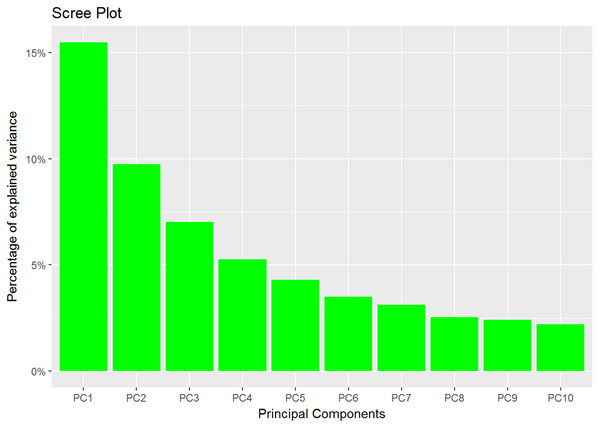

```r
#Order the levels of the factor PC
PCAgenesdf$PC <- ordered(PCAgenesdf$PC, levels = paste0("PC", seq(1 : 10)))

#I create the barplot
#install.packages("ggplot2")
library(ggplot2)
#install.packages("scales") for including percentage
library(scales)
bars <- ggplot(data = PCAgenesdf, aes(x = PC, y = value)) + geom_bar(stat = "identity", fill = "green") +
  xlab("Principal Components") + ylab("Percentage of explained variance") + scale_y_continuous(labels = percent) + ggtitle("Scree Plot")
#I prefer a more lively color and to plot percentages with the % sign
bars
```

. the first two components, highlighting Primary Tumor vs Solid Tissue Normal classification.

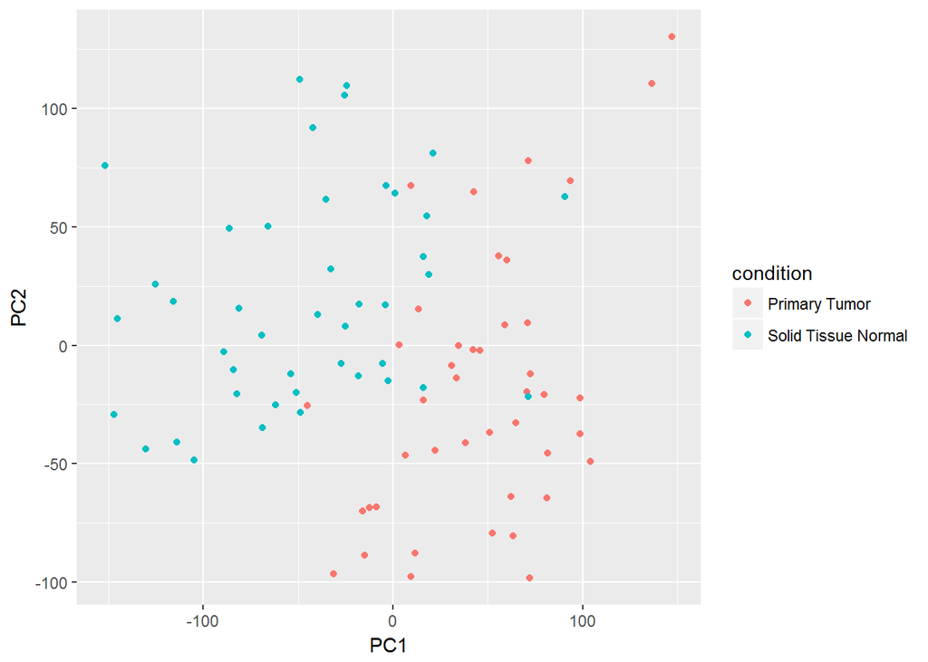

```r
#I add the column with type of tissue classification
classification <- as.factor(unlist(PRADsample[ , 2]))


#I plot the projection onto the first two components
points <- ggplot(data = as.data.frame(PCAgenes$x), aes(x = PC1, y = PC2, color = classification)) + geom_point() + scale_color_discrete(name = "condition")
points
```

For both points, use functions from ggplot2 package and function grid.arrange() from package gridExtra to create the plot.

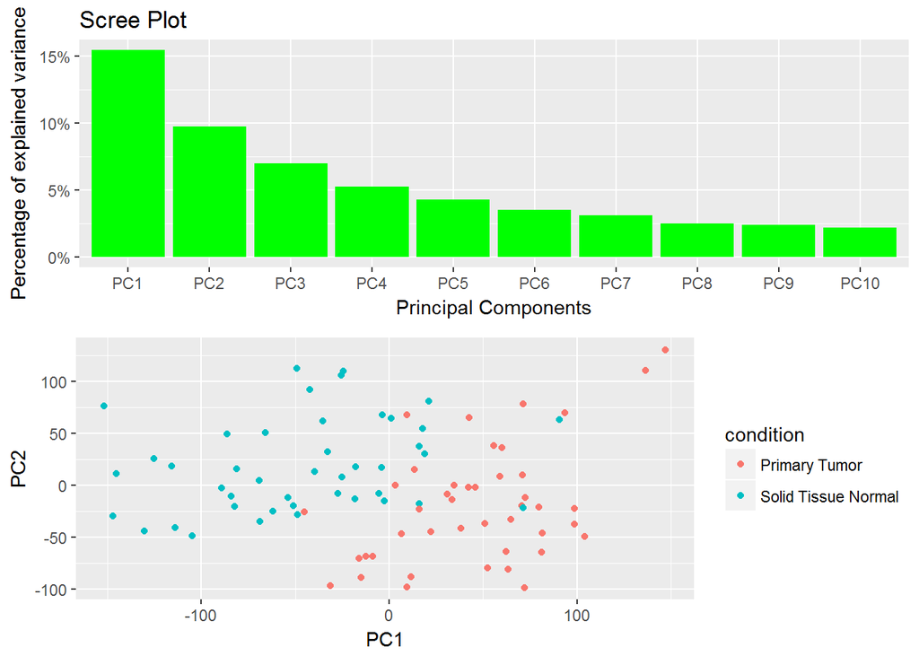

```r
#I arrange the plots within the same figure
#install.packages("gridExtra")
library(gridExtra)
plots <- list(bars, points)
do.call(grid.arrange, plots)
```

## Exercise 2

Perform k-means clustering of all the samples. Set the number of clusters to k=2. Display in a table how samples are distributed across the two clusters with respect to the classification “Primary Tumor” vs “Solid Tissue Normal”. Use function kable() from knitr package in your Rmarkdown.

```r
#I do the k-means clustering and save it under the variable name kmeansgenes
kmeansgenes <- kmeans(t(PRADnormmatrixscaled), centers = 2, nstart = 100)

#I create the table comparing cluster classification with real classification
#install.packages("knitr")
library(knitr)
kable(table(kmeansgenes$cluster, PRADsample[ , 2]))
```

| Primary Tumor | Solid Tissue Normal |
| --- | --- |
| 42 | 10 |
| 1 | 33 |

Then load the file “RES_DESeq2_PRAD.txt” in your R workspace. Starting from the scaled log2-transformed data, extract the sub-matrix keeping the top 250 differentially expressed genes between primary tumors and solid normal tissues with the lowest p-value and repeat the clustering. (NOTE: use the command order). What happens to the clustering results with respect to the classification “Primary Tumor” vs “Solid Tissue Normal”? NOTE: k-means uses a random starting solution and thus different runs can lead to different results. Therefore, trying several random starts is often recommended. Set the parameter “nstart” equal to 100.

```r
#I upload the new dataframe and check that it looks reasonable
PRADpvalues <- read.table("D:\\BMI715 Computing Skills for Biomedical Sciences\\Homework4\\RES_DESeq2_PRAD.txt",
                       header = TRUE, sep = "")
PRADpvalues[1 : 10, 1 : 5]
```

```
##            baseMean log2FoldChange      lfcSE        stat       pvalue
## TSPAN6   4566.80873   -0.005656142 0.09671310 -0.05848372 9.533633e-01
## TNMD       26.29104   -1.374897819 0.32652756 -4.21066394 2.546213e-05
## DPM1     1586.60727   -0.187201681 0.06278721 -2.98152594 2.868157e-03
## SCYL3    1332.80629    0.164029587 0.07327866  2.23843582 2.519265e-02
## C1orf112  252.42867   -0.023198092 0.07798493 -0.29746891 7.661085e-01
## FGR       324.97614   -0.307400293 0.14424650 -2.13107628 3.308286e-02
## CFH      2025.06551   -1.065083117 0.18423406 -5.78114130 7.419554e-09
## FUCA2    3674.63067    0.556293570 0.08560514  6.49836618 8.119698e-11
## GCLC     3652.73876   -0.262641067 0.08930875 -2.94082121 3.273434e-03
## NFYA     2113.81499    0.242489570 0.07070881  3.42941112 6.048925e-04
```

```r
#I order the new dataframe by p values and check that it looks reasonable
PRADpvalues <- PRADpvalues[order(PRADpvalues$pvalue), ]
PRADpvalues[1 : 10, 1 : 5]
```

```
##              baseMean log2FoldChange      lfcSE      stat       pvalue
## SLIT1      711.050551       2.809551 0.23580783  11.91458 9.936563e-33
## EPHA10     400.861359       1.820425 0.15449701  11.78292 4.781032e-32
## CTF1       684.683513      -1.505533 0.12836350 -11.72867 9.087346e-32
## LINC01475    8.463937       4.431921 0.38058650  11.64498 2.433884e-31
## TRIP6     2971.303615      -1.299372 0.11209227 -11.59198 4.525289e-31
## GSTP1     9450.052488      -1.722404 0.14987494 -11.49228 1.442567e-30
## GATM       979.026988      -1.543147 0.13544747 -11.39295 4.533578e-30
## DOK4      1412.169428      -1.126587 0.09969596 -11.30023 1.308800e-29
## AMACR     5145.778450       2.753618 0.24495553  11.24130 2.556004e-29
## BEND5      260.643840      -1.320554 0.11857051 -11.13728 8.259938e-29
```

```r
#I select the top 250 differentially expressed genes and check that it looks reasonable
PRADpvalues <- PRADpvalues[1 : 250, ]
PRADpvalues[1 : 10, 1 : 5]
```

```
##              baseMean log2FoldChange      lfcSE      stat       pvalue
## SLIT1      711.050551       2.809551 0.23580783  11.91458 9.936563e-33
## EPHA10     400.861359       1.820425 0.15449701  11.78292 4.781032e-32
## CTF1       684.683513      -1.505533 0.12836350 -11.72867 9.087346e-32
## LINC01475    8.463937       4.431921 0.38058650  11.64498 2.433884e-31
## TRIP6     2971.303615      -1.299372 0.11209227 -11.59198 4.525289e-31
## GSTP1     9450.052488      -1.722404 0.14987494 -11.49228 1.442567e-30
## GATM       979.026988      -1.543147 0.13544747 -11.39295 4.533578e-30
## DOK4      1412.169428      -1.126587 0.09969596 -11.30023 1.308800e-29
## AMACR     5145.778450       2.753618 0.24495553  11.24130 2.556004e-29
## BEND5      260.643840      -1.320554 0.11857051 -11.13728 8.259938e-29
```

```r
#I create a limited version of the original matrix where only the top 250 differentially expressed genes are present and check that it looks reasonable
PRADnormlimited <- PRADnormmatrixscaled[rownames(PRADpvalues), ]
PRADnormlimited[1 : 10, 1 : 5]
```

```
##           TCGA_HC_8260_11A TCGA_HC_8259_11A TCGA_EJ_7123_11A
## SLIT1           -1.0837829       -1.2103624       -1.0712749
## EPHA10          -0.7442615       -0.7860371       -1.4125806
## CTF1             0.9447149        0.5853768        1.8867708
## LINC01475       -0.9446759       -0.1902346       -0.9446759
## TRIP6            0.6677154        0.5172506        1.6918504
## GSTP1            0.6733880        0.6156462        0.7097558
## GATM             0.3403074        0.2676947        1.6898701
## DOK4             0.6564070        0.6000522        1.3751870
## AMACR           -1.2446631       -1.0503532       -0.5514659
## BEND5            0.7279645        0.8266161        1.2698005
##           TCGA_G9_6496_01A TCGA_EJ_7781_01A
## SLIT1          -0.64186341        1.4555808
## EPHA10          1.10280518        0.8019181
## CTF1           -0.91117831       -0.6146569
## LINC01475       2.20486177        0.7355249
## TRIP6           0.05275005       -1.0162110
## GSTP1          -0.66370490       -0.8965549
## GATM           -0.97692227       -0.2291437
## DOK4           -0.89087433       -1.1896860
## AMACR           0.50307076        1.0928566
## BEND5          -0.85415741       -0.4326828
```

```r
#I repeat the clustering in this limited dataset
kmeansgeneslimited <- kmeans(t(PRADnormlimited), centers = 2, nstart = 100)

#I compare the results
kable(table(kmeansgeneslimited$cluster, PRADsample[ , 2]))
```

| Primary Tumor | Solid Tissue Normal |
| --- | --- |
| 2 | 40 |
| 41 | 3 |

```r
#ANSWER 2:
#The classification gets better with only 5 samples missclassified (as compared to 11 samples missclassified above)
```

## Exercise 3

Using the sub matrix on the top 250 genes, repeat the k-means clustering by genes using k=2 and plot the results using the function clusplot() of the package cluster.

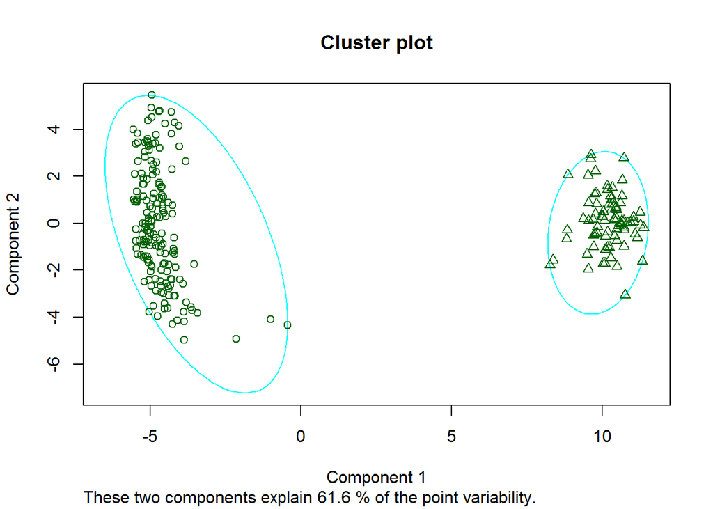

```r
#install.packages("cluster")
library(cluster)

#I repeat the clustering in this limited dataset
kmeansgeneslimited <- kmeans(PRADnormlimited, centers = 2, nstart = 100)

#I plot the results with clusplot
clusplot(PRADnormlimited, kmeansgeneslimited$cluster, line = 0, main = "Cluster plot")
```

To understand how well the clusters are separated, calculate and plot in the same window the silhouettes for both k=2 and k=3. Comment the obtained results. NOTE: Use function silhouette() from package fpc.

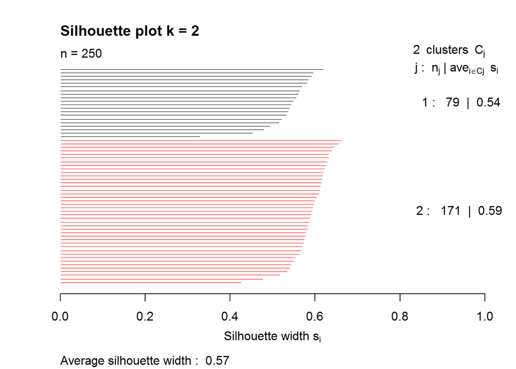

```r
#install.packages("fpc")
library(fpc)

#I repeat the clustering in this limited dataset for k = 2
kmeansgeneslimitedk2 <- kmeans(PRADnormlimited, centers = 2, nstart = 100)

#I create the silhouette and plot it
silk2 <- silhouette(kmeansgeneslimitedk2$cluster, dist(PRADnormlimited))
plot(silk2, col = 1:2, main = "Silhouette plot k = 2")
```

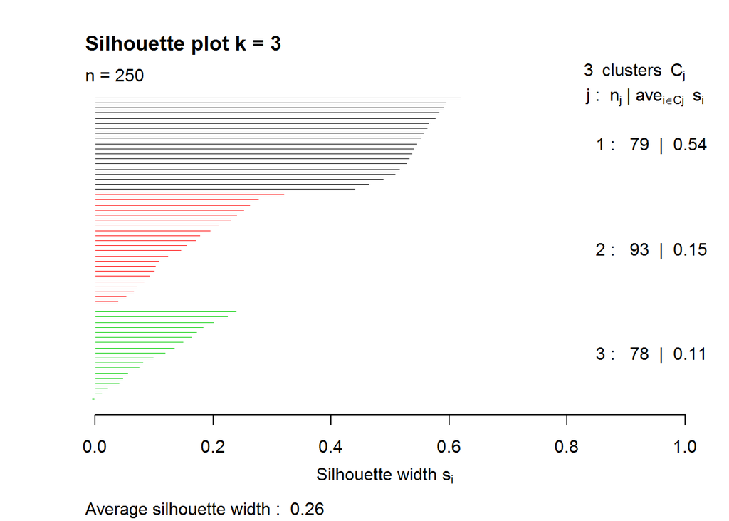

```r
#I repeat the clustering in this limited dataset for k = 3
kmeansgeneslimitedk3 <- kmeans(PRADnormlimited, centers = 3, nstart = 100)

#I create the silhouette and plot it
silk3 <- silhouette(kmeansgeneslimitedk3$cluster, dist(PRADnormlimited))
plot(silk3, col = 1:3, main = "Silhouette plot k = 3")
```

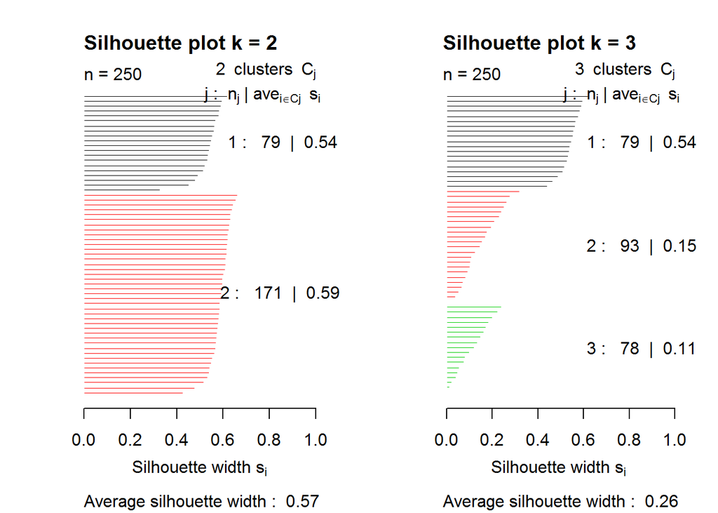

```r
#Now I display the plots within the same window
par(mfrow = c(1, 2))
plot(silk2, col = 1:2, main = "Silhouette plot k = 2")
plot(silk3, col = 1:3, main = "Silhouette plot k = 3")
```

```r
## ANSWER 3:
#The silhouette measures how similar an item is to its own cluster. The value ranges from - 1 to 1. A high value means that the object is similar to its own cluster and dissimilar from other clusters. Therefore, values close to 1 are preferable. Based on the graphs below, it appears that 2 centers yields a more sensible result because the silhouette value of most items are around 0.4-0.6 while for 3 centers the silhouette value of many items decreases to the 0.1-0.2 with only a few clusters maintaining the 0.4-0.6 values. This is reflected in the average silhouettes that decreases from 0.57 with 2 clusters to 0.26 with 3 clusters.
```